# Assignment 6

## Chad Pickering | 913328497 | March 19, 2017

Corresponded with: Edie Espejo, Graham Smith, Nivi Achanta, Patrick Vacek, Ricky Safran, Janice Luong, Sierra Tevlin

**I had to do a majority of 1.2 on Edie Espejo's machine that could actually download geopandas successfully, so if any output has her machine's information in it, that is why.**

In this assignment, you'll analyze a collection of data sets from the [San Francisco Open Data Portal](http://data.sfgov.org/) and [Zillow](https://www.zillow.com/). The data sets have been stored in the SQLite database `sf_data.sqlite`, which you can [download here](http://anson.ucdavis.edu/~nulle/sf_data.sqlite). The database contains the following tables:

| Table | Description |
| --- | --- |
| `crime` | Crime reports dating back to 2010. |
| `mobile_food_locations` | List of all locations where mobile food vendors sell. |
| `mobile_food_permits` | List of all mobile food vendor permits. More details [here](https://data.sfgov.org/api/views/rqzj-sfat/files/8g2f5RV4PEk0_b24iJEtgEet9gnh_eA27GlqoOjjK4k?download=true&filename=DPW_DataDictionary_Mobil… |
| `mobile_food_schedule` | Schedules for mobile food vendors. |
| `noise` | Noise complaints dating back to August 2015. |
| `parking` | List of all parking lots. |
| `parks` | List of all parks. |
| `schools` | List of all schools. |
| `zillow` | Zillow rent and housing statistics dating back to 1996. More details [here](https://www.zillow.com/research/data/). |

The `mobile_food_` tables are explicitly connected through the `locationid` and `permit` columns. The other tables are not connected, but you may be able to connect them using dates, latitude/longitude, or postal codes.

Shapefiles for US postal codes are available [here](https://www.census.gov/geo/maps-data/data/cbf/cbf_zcta.html). These may be useful for converting latitude/longitude to postal codes.

Shapefiles for San Francisco Neighborhoods are available [here](https://data.sfgov.org/Geographic-Locations-and-Boundaries/SF-Find-Neighborhoods/pty2-tcw4).

**Exercise 1.1.** Which mobile food vendor(s) sells at the most locations?

```python
# Import packages:
import pandas as pd
from matplotlib import pyplot as plt
import sqlalchemy as sqla
%matplotlib inline
plt.style.use('ggplot')
plt.rcParams['figure.figsize'] = (12, 12)
import numpy as np
import sqlite3 as sql
from mpl_toolkits.basemap import Basemap
import geopandas as gpd
import shapely.geometry as geom
from scipy.stats.stats import pearsonr
import math
import seaborn as sos
```

```python
# Connect to database:
db = sql.connect("sf_data.sqlite")
```

```python
# 1.1 query:
df = pd.read_sql("SELECT mobile_food_locations.Address, mobile_food_permits.Applicant, count(*) \
                    FROM mobile_food_locations \
                    INNER JOIN mobile_food_permits \
                    ON mobile_food_permits.permit = mobile_food_schedule.permit \
                    INNER JOIN mobile_food_schedule \
                    ON mobile_food_locations.locationid = mobile_food_schedule.locationid \
                    WHERE status=='APPROVED' \
                    GROUP BY Address \
                    ORDER BY count(*)", db)
df['Applicant'].value_counts().head(5) # Count the values
```

```
Park's Catering    22
D & T Catering     17
F & C Catering     13
Munch A Bunch       9
Eva's Catering      8
Name: Applicant, dtype: int64
```

The top 5 vendors that sell food at the most locations are the following: **Park's Catering, D&T Catering, F&C Catering, Munch A Bunch, and Eva's Catering**, with the most being Park's with a total of 22 locations.

**Exercise 1.2.** Ask and use the database to analyze 5 questions about San Francisco. For each question, write at least 150 words and support your answer with plots. Make a map for at least 2 of the 5 questions.

You should try to come up with some questions on your own, but these are examples of reasonable questions:

- Which parts of the city are the most and least expensive?
- Which parts of the city are the most dangerous (and at what times)?
- Are noise complaints and mobile food vendors related?
- What are the best times and places to find food trucks?
- Is there a relationship between housing prices and any of the other tables?

Please make sure to clearly state each of your questions in your submission.

**Question 1: Where do crimes happen the most in San Francisco? Is there a significant difference between the types of crimes committed in all police districts and the police district with the most crimes? What can we say about the most frequent crime category in terms of the days of the week on which it happens?**

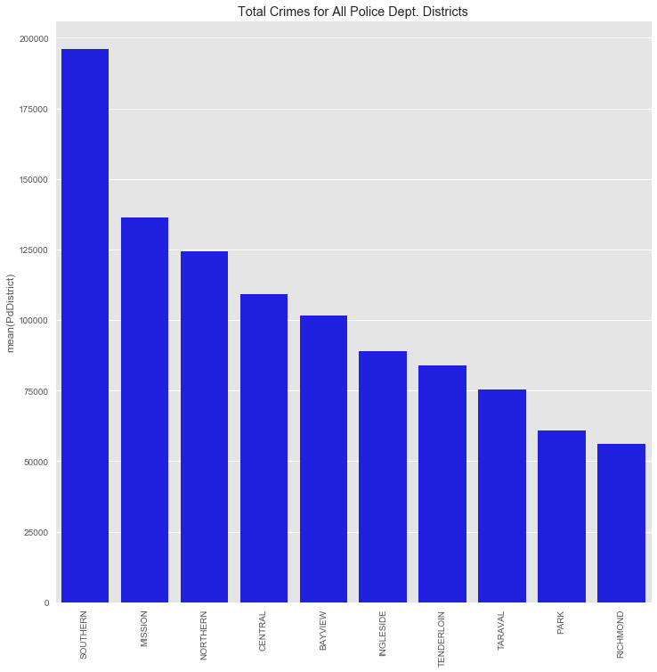

```python
crime = pd.read_sql("SELECT Descript, PdDistrict, Lon, Lat \
                        FROM crime", db)

# Districts subsetted
districts = pd.DataFrame(crime["PdDistrict"].value_counts())
plot1 = sos.barplot(x=districts.index.values, y=districts["PdDistrict"], data=districts,
            label="Total", color="blue")
for item in plot1.get_xticklabels():
    item.set_rotation(90)
plt.title("Total Crimes for All Police Dept. Districts")
plt.show()
```

It clearly appears that **Southern District** has the most crime. However, the districts following also show an interestingly descending frequency of crime reported. Let's see if the most frequently committed crimes are different for Southern District in comparison with the entire body of crimes.

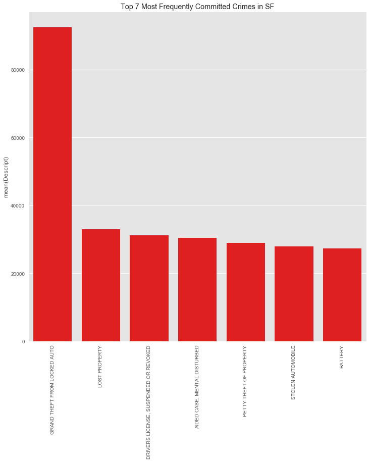

```python
# Crime types:
crime_types = pd.DataFrame(crime["Descript"].value_counts())
plot2 = sos.barplot(x=crime_types.index.values[0:7], y=crime_types["Descript"][0:7], data=crime_types,
            label="Total", color="red")
for item in plot2.get_xticklabels():
    item.set_rotation(90)
plt.title("Top 7 Most Frequently Committed Crimes in SF")
plt.show()
```

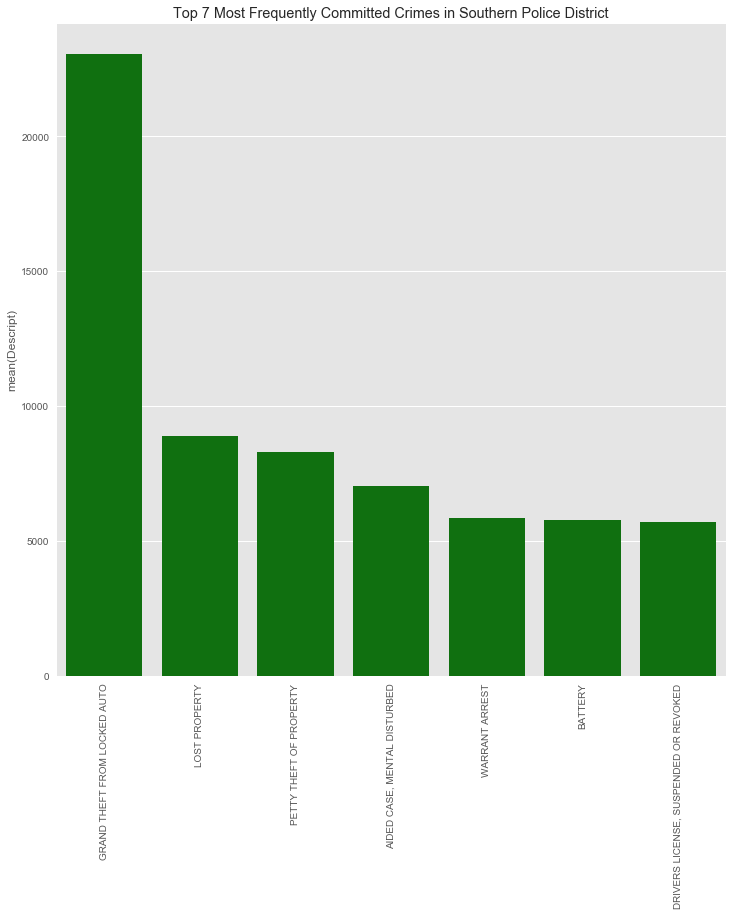

```python
# Crime types in Southern Police District:
crime_southern = pd.read_sql("SELECT Descript, PdDistrict, Lon, Lat \
                        FROM crime \
                        WHERE PdDistrict = 'SOUTHERN'", db)
crime_types = pd.DataFrame(crime_southern["Descript"].value_counts())
plot2 = sos.barplot(x=crime_types.index.values[0:7], y=crime_types["Descript"][0:7], data=crime_types,
            label="Total", color="green")
for item in plot2.get_xticklabels():
    item.set_rotation(90)
plt.title("Top 7 Most Frequently Committed Crimes in Southern Police District")
plt.show()
```

By far, the most common crime in SF is **grand theft from a locked automobile**. In Southern District, the trend is disturbingly the same, and the crime rates for the other top categories are roughly homogeneous with respect to the entire city. This suggests that Southern District is a fair representation of the crime committed in San Francisco, and if a random sample of crimes were taken from Southern District to represent the entire city, the results would not be too far off. Of course, with the data provided, we would rather simply randomly sample from the entire city, but if it was needed the other choice (with less data, and therefore effort and/or money) would be reasonable.

Now, let's look at grand theft from locked vehicles and see if this is more common on certain days of the week, and whether this happens in certain locations more often on those days. We can see that there is an **uptick in grand theft on Fridays and Saturdays** in contrast to the other days of the week below.

```python
crime_grandtheft = pd.read_sql("SELECT DayOfWeek, Lon, Lat \
                        FROM crime \
                        WHERE Descript = 'GRAND THEFT FROM LOCKED AUTO'", db)
crime_grandtheft["DayOfWeek"].value_counts()
```

```
Saturday     14518
Friday       14473
Wednesday    12913
Thursday     12854
Sunday       12705
Tuesday      12569
Monday       12366
Name: DayOfWeek, dtype: int64
```

Now let's plot Friday and Saturday's grand thefts on a map and see if there is a stark visual difference in terms of where these occur.

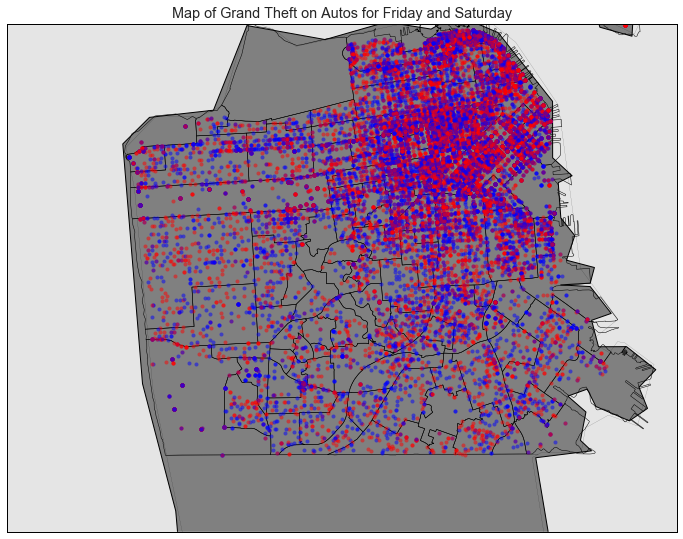

```python
crime_grandtheft = pd.read_sql("SELECT DayOfWeek, Lon, Lat \
                        FROM crime \
                        WHERE Descript = 'GRAND THEFT FROM LOCKED AUTO' \
                        AND DayOfWeek IN ('Friday', 'Saturday')", db)
gt_map = Basemap(projection="merc", llcrnrlon=-122.55, llcrnrlat=37.69, urcrnrlon=-122.35, urcrnrlat=37.81, resolution="h", area_thresh = 0.1)

gt_map.drawcoastlines()
gt_map.drawmapboundary()
gt_map.drawcounties()
gt_map.readshapefile("SF Find Neighborhoods/geo_export_dd4c4138-2501-498e-86f4-06d7827b2d53", "geo_export_dd4c4138-2501-498e-86f4-06d7827b2d53")
gt_map.fillcontinents(color="grey")

for lon, lat, day in zip(crime_grandtheft.Lon, crime_grandtheft.Lat, crime_grandtheft.DayOfWeek):
    x, y = gt_map(lon, lat)
    color = "b"
    if (day == "Saturday"):
        color = "r"
    gt_map.plot(x, y, color + "o", markersize = 4, alpha = 0.5)

plt.title("Map of Grand Theft on Autos for Friday and Saturday")
plt.show()
```

**KEY:** Blue - Friday | Red - Saturday

Assuming that all districts have complete data, we can see that perhaps in specific smaller regions of the city, there are very small differences as to where grand thefts occur on Fridays versus Saturdays, but in general, both days have both a similar amount of grand thefts and roughly the same distribution. Grand thefts, on Fridays and Saturdays at least, are very concentrated in the northeastern quadrant of the city, where everywhere else has a mild to moderate seemingly uniform sprinkling. There are some specifically small regions like Golden Gate Park and central residential areas that have a significantly reduced rate of grand thefts in general.

**Question 2: Determine where homicides happen most often. Where specifically are homicides most common in city limits? How are these homicides committed? When the most common homicide type is discovered, what districts is this type most common?**

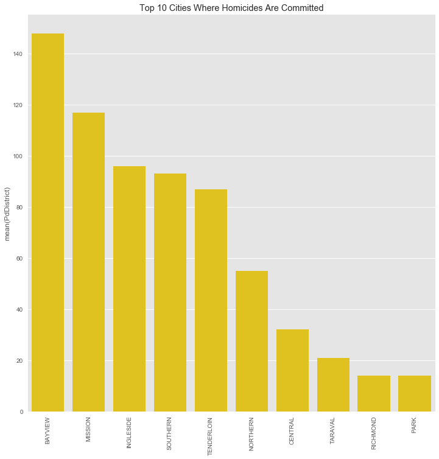

```python
# Homicides:
crime_h = pd.read_sql("SELECT Descript, PdDistrict, Lon, Lat \
                        FROM crime \
                        WHERE Descript LIKE '%HOMICIDE%'", db)
crime_types = pd.DataFrame(crime_h["PdDistrict"].value_counts())
crime_types
plot2 = sos.barplot(x=crime_types.index.values[0:10], y=crime_types["PdDistrict"][0:10], data=crime_types,
            label="Total", color="gold")
for item in plot2.get_xticklabels():
    item.set_rotation(90)
plt.title("Top 10 Cities Where Homicides Are Committed")
plt.show()
```

Homicides are more common in the Bayview and Mission police districts. We see that in general there is no trend present that suggests that there are two or three distinct groups, for example a group of districts with similarly high rates, a group of districts with similarly low rates, etc. It would be nice to know exactly where homicides occur, and where some types of homicides occur more often. A map follows.

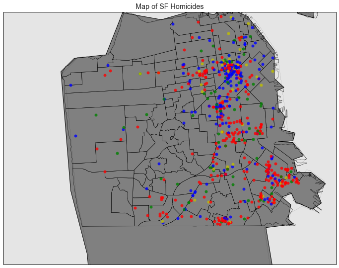

```python
homicides = pd.read_sql("SELECT Descript, PdDistrict, Lon, Lat \
                            FROM crime \
                            WHERE Descript LIKE '%HOMICIDE%'", db)
homicide_map = Basemap(projection="merc", llcrnrlon=-122.55, llcrnrlat=37.69, urcrnrlon=-122.35, urcrnrlat=37.81, resolution="h", area_thresh = 0.1)

homicide_map.drawcoastlines()
homicide_map.drawmapboundary()
homicide_map.drawcounties()
homicide_map.readshapefile("SF Find Neighborhoods/geo_export_dd4c4138-2501-498e-86f4-06d7827b2d53", "geo_export_dd4c4138-2501-498e-86f4-06d7827b2d53")
homicide_map.fillcontinents(color="grey")

for lon, lat, desc in zip(homicides.Lon, homicides.Lat, homicides.Descript):
    x, y = homicide_map(lon, lat)
    color = "g"
    if desc == "ATTEMPTED HOMICIDE WITH BODILY FORCE":
        color = "y"
    if desc == "ATTEMPTED HOMICIDE WITH A GUN":
        color = "r"
    if desc == "ATTEMPTED HOMICIDE WITH A KNIFE":
        color = "b"
    homicide_map.plot(x, y, color + "o", markersize = 6, alpha = 0.8)

plt.title("Map of SF Homicides")
plt.show()
```

**KEY:** Red - Gun | Green - Dangerous Weapon | Blue - Knife | Yellow - Bodily Force

Homicides occur specifically along major roads/freeways, and in areas that are visited by tourists and locals frequently; it seems like the east half of the city is far more active in terms of homicides generally (and is more touristy). Residential areas in the central parts of the city do not have a high homicide rate, which is wonderful news.

Where there exists an epicenter of homicide, it seems like homicides by knife are more common in northeastern SF, whereas homicide by gun is more prevalent in southeastern SF. Homicides by bodily force and by dangerous weapon seem spread rather evenly in the same general distribution as all homicides. A barplot follows showing the relative frequencies of homicide types.

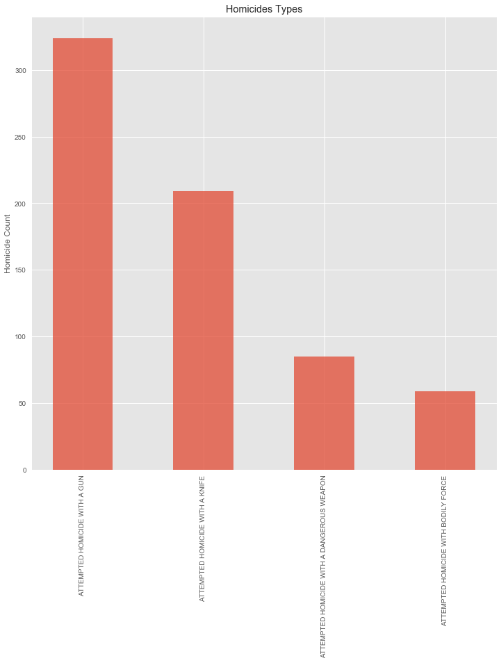

```python
hom_types = pd.DataFrame(homicides["Descript"].value_counts())
hom_list = list(hom_types.index.values)
y_pos = np.arange(len(hom_list))
plt.bar(y_pos, hom_types["Descript"], alpha = 0.75, width=0.5)
plt.xticks(y_pos, hom_list, rotation = "vertical")
plt.ylabel("Homicide Count")
plt.title("Homicides Types")
plt.show()
```

We see that homicides with a gun are most common, and that homicide by knife is not that far behind. Let's see where these particular homicides by gun occur.

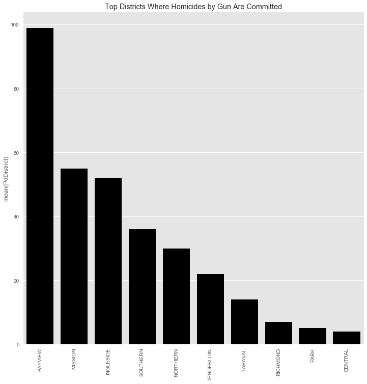

```python
gun = homicides[homicides["Descript"]=="ATTEMPTED HOMICIDE WITH A GUN"]
gun_dist = pd.DataFrame(gun["PdDistrict"].value_counts())
plot4 = sos.barplot(x=gun_dist.index.values[0:10], y=gun_dist["PdDistrict"][0:10], data=gun_dist,
            label="Total", color="black")
for item in plot4.get_xticklabels():
    item.set_rotation(90)
plt.title("Top Districts Where Homicides by Gun Are Committed")
plt.show()
```

By far, the Bayview district has the most homicide by gun when comparing with the other districts, and the next few are in the same order (in terms of frequency) as all homicide frequencies (chart shown above).

**Question 3: Are parking garages more common adjacent to water and/or major roads? What other visual trends are apparent? How can the distributions of lot capacities be compared?**

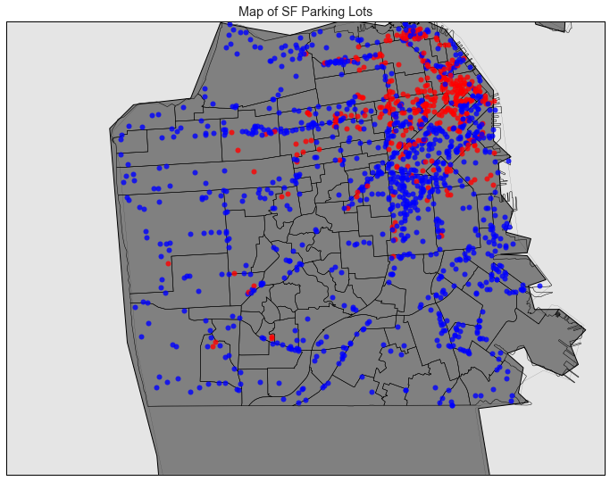

```python
# Garage or Lot
parking = pd.read_sql("SELECT * \
            FROM parking \
            WHERE GarOrLot IN ('G', 'L') \
            AND Lat > 0 AND Lon < 0", db)

parking_map = Basemap(projection="merc", llcrnrlon=-122.55, llcrnrlat=37.69, urcrnrlon=-122.35, urcrnrlat=37.81, resolution="h", area_thresh = 0.1)

parking_map.drawcoastlines()
parking_map.drawmapboundary()
parking_map.drawcounties()
parking_map.readshapefile("SF Find Neighborhoods/geo_export_dd4c4138-2501-498e-86f4-06d7827b2d53", "geo_export_dd4c4138-2501-498e-86f4-06d7827b2d53")
parking_map.fillcontinents(color="grey")

for lon, lat, t in zip(parking.Lon, parking.Lat, parking.GarOrLot):
    x, y = parking_map(lon, lat)
    color = "r"
    if t == "L":
        color = "b"
    parking_map.plot(x, y, color + "o", markersize = 6, alpha = 0.8)

plt.title("Map of SF Parking Lots")
plt.show()
```

**KEY:** Red - Parking Garages | Blue - Parking Lots

It is apparent that parking garages, which can hold far more vehicles since they are vertical as well, are far more common in northeastern SF where the financial district and touristy regions typically hold more people in such a congested space. The Embarcadero area specifically has a great deal of parking garages nearby. Parking lots, though, are far more common in areas where space is more spread out relative to the dense city areas, such as east-central city and along Golden Gate Park. The use of parking lots elsewhere is awfully common along major roads where parking is needed for markets, workplaces, and other facilities. So, in conclusion, water appears to have nothing to do with the density of parking lots; it is the location and relative utility of them that determines their density in a particular region.

Now I would like to know the distribution of the capacities of parking garages and parking lots in SF.

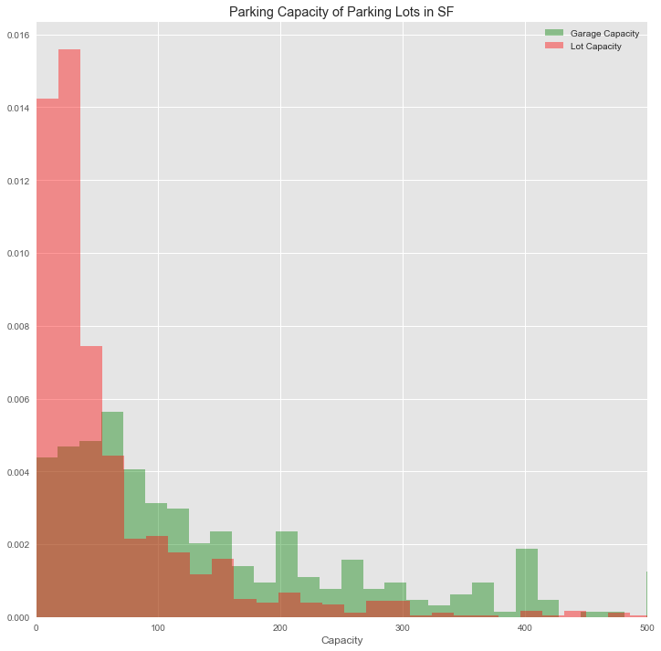

```python
garages_g = parking[parking["GarOrLot"]=="G"]
garages_dist_g = garages_g.loc[:,"RegCap"]
g_list_g = garages_dist_g.tolist()
n, bins, patches = plt.hist(g_list_g, 145, normed=1, facecolor='green', alpha=0.4, label = 'Garage Capacity')

garages_l = parking[parking["GarOrLot"]=="L"]
garages_dist_l = garages_l.loc[:,"RegCap"]
g_list_l = garages_dist_l.tolist()
n, bins, patches = plt.hist(g_list_l, 500, normed=1, facecolor='red', alpha=0.4, label = 'Lot Capacity')
plt.xlabel('Capacity')
plt.title('Parking Capacity of Parking Lots in SF')
plt.xlim(0, 500)
plt.legend(loc='upper right')
plt.show()
```

Parking lot capacity is far more **skewed right** with far more parking lots under 100 capacity than parking garages, as logically expected. Lots outnumber garages almost three-fold; the average garage capacity is around 215 (median 116), whereas lots have about 85 spots on average (median 30.5). The abundance of small businesses throughout the city (and relatively small private lots) lower the mean of the parking lots making the difference between garages more stark.

An odd finding is the lot of size 9000; this was determined to be Candlestick Park via SQL. Such influential values affects the mean and variance quite a bit; these could be removed if more analysis was performed.

```python
garages_df = pd.DataFrame(garages_dist_g.describe())
lots_df = pd.DataFrame(garages_dist_l.describe())
parking_desc_df = pd.concat([garages_df, lots_df], axis=1)
parking_desc_df.columns = ['garages', 'lots']
parking_desc_df
```

|  | garages | lots |
| --- | --- | --- |
| count | 359.000000 | 1002.000000 |
| mean | 214.688022 | 85.140719 |
| std | 278.866696 | 341.877824 |
| min | 0.000000 | 0.000000 |
| 25% | 58.000000 | 17.000000 |
| 50% | 116.000000 | 30.500000 |
| 75% | 263.000000 | 70.750000 |
| max | 2585.000000 | 9000.000000 |

**Question 4: Do noise complaints occur more often next to parks? If so, which kind of parks? What other observations can we make here?**

```python
noise = pd.read_sql("SELECT Type, Neighborhood, Lat, Lon \
                FROM noise \
                WHERE Lat > 0 AND Lon < 0", db)
parks = pd.read_sql("SELECT Type, Acreage, Lat, Lon \
                FROM parks \
                WHERE Lat > 0 AND Lon < 0", db)
pd.DataFrame(parks.loc[:,'Type'].value_counts())
```

|  | Type |
| --- | --- |
| Neighborhood Park or Playground | 123 |
| Mini Park | 45 |
| Community Garden | 12 |
| Civic Plaza or Square | 9 |
| Regional Park | 8 |
| Concession | 2 |
| Parkway | 1 |
| Zoological Garden | 1 |
| Family Camp | 1 |

Neighborhood parks/playgrounds are abundant in SF, as well as mini-parks. We see some categories have very few members, so in the upcoming plot, we will combine some categories. Just for fun, let's briefly see if mini-parks really are smaller than all other parks.

```python
mini_parks = pd.read_sql("SELECT Type, Acreage, Lat, Lon \
                FROM parks \
                WHERE Lat > 0 AND Lon < 0 \
                AND Type == 'Mini Park'", db)

other_parks = pd.read_sql("SELECT Type, Acreage, Lat, Lon \
                FROM parks \
                WHERE Lat > 0 AND Lon < 0 \
                AND (Type == 'Neighborhood Park or Playground' OR Type == 'Regional Park')", db)

mini = pd.DataFrame(mini_parks.loc[:,"Acreage"].describe())
other = pd.DataFrame(other_parks.loc[:,"Acreage"].describe())

parks_df = pd.concat([mini, other], axis=1)
parks_df.columns = ['mini', 'other']
parks_df
```

|  | mini | other |
| --- | --- | --- |
| count | 45.000000 | 131.000000 |
| mean | 0.276000 | 19.707634 |
| std | 0.296168 | 100.353861 |
| min | 0.000000 | 0.000000 |
| 25% | 0.120000 | 0.865000 |
| 50% | 0.160000 | 2.520000 |
| 75% | 0.320000 | 6.300000 |
| max | 1.740000 | 1031.980000 |

Judging from the descriptive statistics and some quick boxplots (not shown), mini-parks are typically under a half-acre, but some are as large as an acre and a half or more. Perhaps some of these parks were misclassified. Same goes for other parks, which should not be smaller than an acre and a half or so, and yet some are. If the classification is this inconsistent here, how inconsistent is it elsewhere in the table or in the entire database?

Now, we will plot the types of parks and all noise complaints and see if these complaints are more likely to occur near parks, and which type(s) specifically.

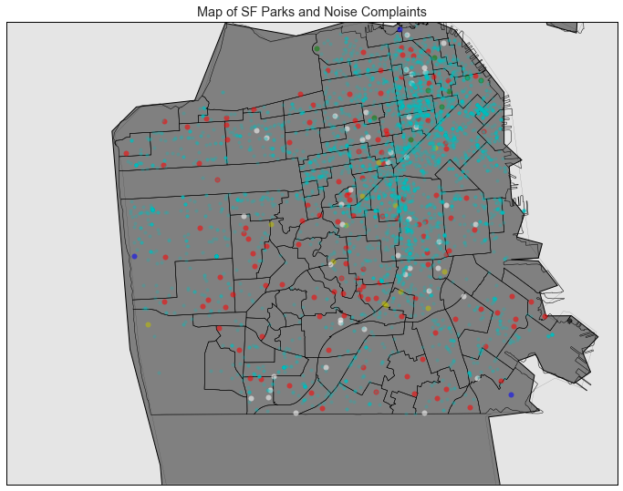

```python
noiseparks_map = Basemap(projection="merc", llcrnrlon=-122.55, llcrnrlat=37.69, urcrnrlon=-122.35, urcrnrlat=37.81, resolution="h", area_thresh = 0.1)

noiseparks_map.drawcoastlines()
noiseparks_map.drawmapboundary()
noiseparks_map.drawcounties()
noiseparks_map.readshapefile("SF Find Neighborhoods/geo_export_dd4c4138-2501-498e-86f4-06d7827b2d53", "geo_export_dd4c4138-2501-498e-86f4-06d7827b2d53")
noiseparks_map.fillcontinents(color="grey")

for lon, lat, t in zip(parks.Lon, parks.Lat, parks.Type):
    x, y = noiseparks_map(lon, lat)
    color = "r"
    if t == "Mini Park":
        color = "w"
    if t == "Community Garden":
        color = "y"
    if t == "Civic Plaza or Square":
        color = "g"
    if t == "Regional Park":
        color = "r"
    if t == "Concession":
        color = "b"
    if t == "Parkway":
        color = "b"
    if t == "Zoological Garden":
        color = "y"
    if t == "Family Camp":
        color = "y"
    noiseparks_map.plot(x, y, color + "o", markersize = 6, alpha = 0.55)

for lon, lat in zip(noise.Lon, noise.Lat):
    x, y = noiseparks_map(lon, lat)
    color = "c"
    noiseparks_map.plot(x, y, color + "o", markersize = 4, alpha = 0.25)

plt.title("Map of SF Parks and Noise Complaints")
plt.show()
```

**KEY:** Cyan - Noise Complaints | Red - Neighborhood Park or Playground AND Regional Park | White - Mini-Park | Green - Civic Plaza or Square | Blue - Concession AND Parkway | Yellow - Community Garden AND Zoological Garden AND Family Camp

We can see that most moise complaints occur along major roads and, as expected by now, the northeastern quadrant of the city. However, it does not look like noise in parks are *consistently* correlated at all with noise complaints. Rather, parks just happen to be located where more noise is likely to be, especially in the northeastern part of the city. However, I see some interesting mild correlation possible in the southern third of the city where most of the city is residential - parks are some of the only venues that attract noise here. We could look at certain radii around parks in the northern two-thirds and southern third and analyze the amount of noise complaints there have been in contrast with each other to see if there is any major difference. The sample size of parks would have to be quite large for any conclusions to be significant.

**Question 5: Is median selling price correlated with residence turnover? And in which zip codes is this most prevalent?**

```python
med_turnover = pd.read_sql("SELECT RegionName, MedianSoldPricePerSqft_AllHomes, Turnover_AllHomes \
                FROM zillow \
                WHERE MedianSoldPricePerSqft_AllHomes > 0 \
                GROUP BY RegionName", db)
med_per_sqft = med_turnover.loc[:,'MedianSoldPricePerSqft_AllHomes'].tolist()
turnover_rate = med_turnover.loc[:,'Turnover_AllHomes'].tolist()
```

The sample size is 25, so any conclusions will have to be taken lightly (but this cannot be fixed, per se, if we still would like to look at zip codes; **blocks** may be a different story). We also have to see if both variables are approximately normally distributed - but with a sample size of 25, this will have to be strikingly visually obvious to consider any results valuable.

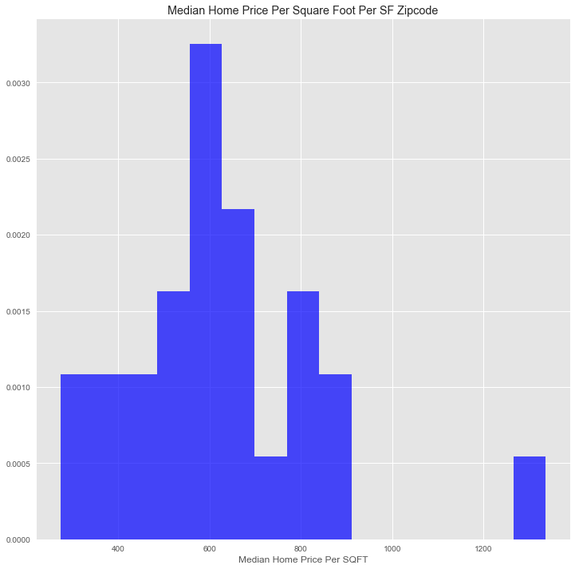

```python
n, bins, patches = plt.hist(med_per_sqft, 15, normed=1, facecolor='blue', alpha=0.7)
plt.xlabel('Median Home Price Per SQFT')
plt.title(r'Median Home Price Per Square Foot Per SF Zipcode')
plt.show()
```

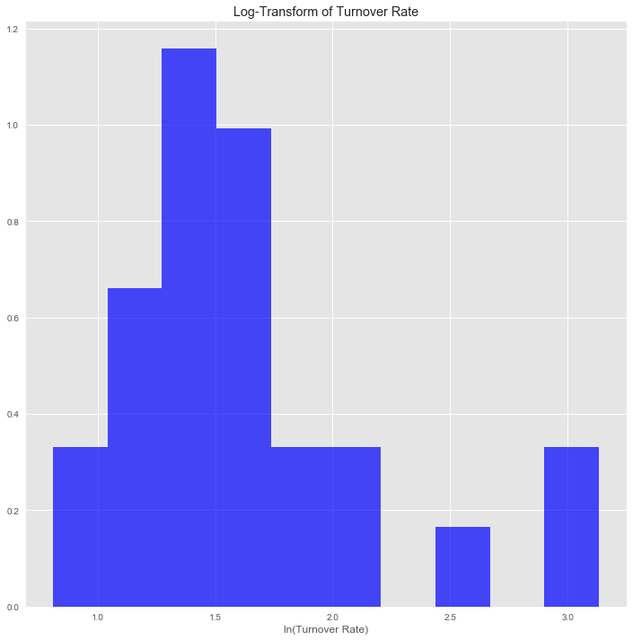

```python
ln_turnover_rate = [math.log(y) for y in turnover_rate] # ln transform
n, bins, patches = plt.hist(ln_turnover_rate, 10, normed=1, facecolor='blue', alpha=0.7)
plt.xlabel('ln(Turnover Rate)')
plt.title(r'Log-Transform of Turnover Rate')
plt.show()
```

From the histograms above, we can see rough normality (both are moderately skewed right though) in both the median selling price per square foot and the log-transformed turnover rate data. Thus, we can continue with our analysis despite the fact that we have had to transform a variable to make a conclusion about linear correlation (but the conclusion will be stated exactly as it should in a moment).

```python
pearson_corr_coeff = pearsonr(med_per_sqft, ln_turnover_rate)[0]
pearson_corr_coeff
```

```
0.42517997389053203
```

The **Pearson's correlation coefficient is about 0.4252**, signaling **mild positive linear correlation** between median selling price per square foot and natural log of turnover rate. This means that, in general, as median home price per square foot increases, turnover rate also increases. This implies that residents in zip codes with generally higher priced homes move more often in San Francisco (with the fact kept in mind that we are making this conclusion of linear correlation WITH a log-transformed variable). It should be noted that when disregarding the skewed nature of the non-transformed turnover rates, the Pearson's correlation coefficient is about 0.3874, but it is questionable whether or not this correlation can be interpretted well given the violation of assumptions. We will now look at which zip codes the median price per square foot is greatest in, and make any other conclusions we can find. (From here on out, we will return to analyzing non-transformed turnover rate.)

```python
med_turnover.sort_values('MedianSoldPricePerSqft_AllHomes', ascending=False).head(8)
```

|  | RegionName | MedianSoldPricePerSqft_AllHomes | Turnover_AllHomes |
| --- | --- | --- | --- |
| 3 | 94104 | 1336.128581 | 22.9730 |
| 9 | 94111 | 901.804100 | 7.2349 |
| 23 | 94133 | 850.666667 | 4.7301 |
| 18 | 94123 | 836.363636 | 4.7030 |
| 14 | 94117 | 777.939300 | 4.4494 |
| 6 | 94108 | 769.973545 | 13.3479 |
| 11 | 94114 | 737.979500 | 4.8151 |
| 4 | 94105 | 666.135881 | 8.6360 |

We can see that the 8 zip codes with the largest median price per square foot in San Francisco have turnover rates that are all above the median rates, except for one. The most expensive zip code is 94104, the financial district downtown; this region also has the highest turnover rate. This supports the positive correlation found above. Additionally, we can look at the map below, where bluer corresponds with more expensive, and redder corresponds with less expensive.

```python
prices_zip = med_turnover.iloc[:,:2]
```

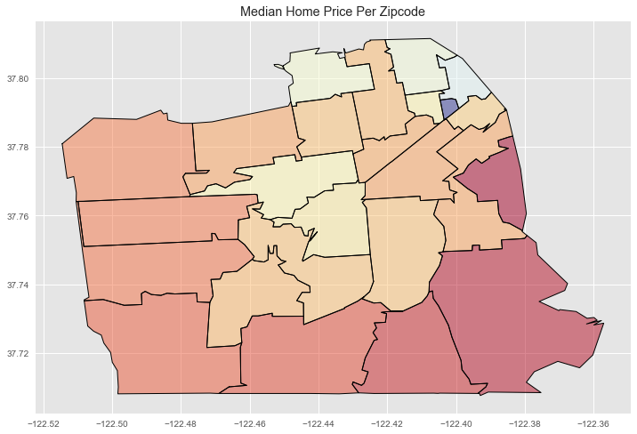

```python
# load, subset
zips = gpd.read_file("zip/cb_2015_us_zcta510_500k.shp")
zips = zips[zips.ZCTA5CE10.str.startswith("9")]
region_zip = [str(x) for x in prices_zip["RegionName"].values]
zips = zips.loc[zips["ZCTA5CE10"].isin(set(region_zip))]

# align zips
zips["RegionName"] = zips["ZCTA5CE10"]
zips = zips.reset_index().sort_values(by="RegionName")
zips = zips[["RegionName", "geometry"]].reset_index(drop=True)

# df merged / median info
prices_zip = prices_zip.reset_index(drop=True).sort_values(by="RegionName")
df_col_merged = pd.concat([zips, prices_zip["MedianSoldPricePerSqft_AllHomes"]], axis=1)

# remove south city - not in SF
df_col_merged = df_col_merged[df_col_merged["RegionName"] != "94080"].reset_index(drop=True)
df_col_merged.plot(column='MedianSoldPricePerSqft_AllHomes', colormap="RdYlBu")
plt.title("Median Home Price Per Zipcode")
```

**KEY:** BLUE = Expensive; RED = Not Expensive

Peace out, Assignment 6, it's been real.

```python
db.close()
```